| G. Jagiella | Podstawowy warsztat AI 2025/26 | ostatnia modyfikacja: 24.10.2025 |
| --- | --- | --- |

# Wykład 4 - metody, moduły, wstęp do rysowania wykresów

Przypomnienie: list (obiekt typu `lst`) - ciąg obiektów, podobny do krotki, ale zmienialny.  
Przybliżony odpowiednik w C++: `std::vector` lub wręcz `std::vector<std::shared_ptr<void>>`.

```python
lst = [1, 2, 3]
print(lst)
```

```
[1, 2, 3]
```

```python
lst[0] = 1000
print(lst)
```

```
[1000, 2, 3]
```

## Metody

**Metoda** (intuicyjnie) - funkcja przywiązana do obiektu.

```python
lst = [1, 2, 3]
lst.append('X') # wywołanie metody append obiektu o nazwie lst
print(lst)
```

```
[1, 2, 3, 'X']
```

Ogólna składnia: `obj.method(...)` gdzie `obj` to obiekt, `method` to nazwa jego metody.

### Przykłady metod list

`pop()`:

```python
lst = [1, 2, 3]
print(lst)
```

```
[1, 2, 3]
```

```python
lst.pop() # bez parametru usuwa i zwraca element z końca listy
```

```
3
```

```python
print(lst)
```

```
[1, 2]
```

`pop(i)` (`i` - indeks):

```python
lst = [1, 2, 3]
print(lst)
```

```
[1, 2, 3]
```

```python
lst.pop(1) # jak pop(), ale usuwa element spod podanego indeksu
```

```
2
```

```python
print(lst)
```

```
[1, 3]
```

`remove(x)`:

```python
lst = list("abcdeabcde")
print(lst)
lst.remove("b") # usuwa pierwsze wystąpienie elementu
print(lst)
```

```
['a', 'b', 'c', 'd', 'e', 'a', 'b', 'c', 'd', 'e']
['a', 'c', 'd', 'e', 'a', 'b', 'c', 'd', 'e']
```

`index(x)`:

```python
lst = [1, 2.0, [], (1,2,3), "aaa"]
lst.index(2.0) # zwraca indeks pod którym pojawia się element
```

```
1
```

Więcej metod list: https://docs.python.org/3/tutorial/datastructures.html#more-on-lists

### Przykłady metod napisów

Napisy nie są zmienialne, zatem żadna metoda napisu nie będzie go modyfikować (ale może zwrócić nowy napis).

```python
s = "Jestem przykładowym napisem."
```

```python
print(s.upper())
```

```
JESTEM PRZYKŁADOWYM NAPISEM.
```

```python
print(s.lower()) # podobnie: s.casefold()
```

```
jestem przykładowym napisem.
```

```python
print(s.count("em")) # liczba wystąpień podnapisu
```

```
2
```

```python
print("Napis".isupper())
print("NAPIS".isupper())
```

```
False
True
```

```python
s = "Jestem przykładowym napisem."
s.split() # zwraca listę, można wybrać separator
```

```
['Jestem', 'przykładowym', 'napisem.']
```

```python
print(s.startswith("Jestem "))
print(s.endswith("m."))
```

```
True
True
```

```python
print(s.replace("przykładowym", "niezwykle ważnym"))
print(s.replace("e", "E"))
```

```
Jestem niezwykle ważnym napisem.
JEstEm przykładowym napisEm.
```

Dużo więcej metod: https://docs.python.org/3/library/stdtypes.html#string-methods

Metody które posiada dany obiekt *zazwyczaj* zależą od jego typu.

Metoda danego obiektu *zazwyczaj* wykonuje operację związaną z tym obiektem (np. modyfikuje go lub zwraca informację o nim).

## Moduły

**Moduł** (intuicyjnie) - paczka z kodem Pythona (zawierająca funkcje, typy, inne obiekty).  
Żeby ich użyć, trzeba je *zaimportować*.

Przykład: `math` - wbudowany moduł dostarczający funkcji (i stałych) matematycznych.

Pierwszy sposób importowania: indywidualne nazwy.

```python
from math import pi, sin, cos, exp
```

```python
print(pi)
print(sin(pi / 2))
print(cos(1))
print(exp(1))
```

```
3.141592653589793
1.0
0.5403023058681398
2.718281828459045
```

Drugi sposób: importowanie całego modułu.

```python
import math
```

Dostęp do obiektów w module ma składnię podobną do wywoływania metod obiektów:

```python
print(math.pi)
print(math.sin(math.pi))
print(math.cos(math.pi))
```

```
3.141592653589793
1.2246467991473532e-16
-1.0
```

**Uwaga.** W istocie wyrażenie `obj.attr` oznacza dostęp do *atrybutu* `attr` obiektu `obj`. Atrybut to nazwa stowarzyszona z obiektem i może nazywać dowolny obiekt. W szczególności taki obiekt może być liczbą (`math.pi`), funkcją (`math.sin`) lub metodą (`lst.append`, gdzie `lst` ot lista).  
Powyżej, `math` to też obiekt (typu `module`).

Moduł `math`: nie tylko analiza matematyczna. Kilka przykładów:

```python
print(math.factorial(10)) # silnia
print(math.comb(6, 4)) # symbol Newtona: 6 po 4
print(math.gcd(15, -21)) # największy wspólny dzielnik
```

```
3628800
15
3
```

Odległość punktów w $\mathbb{R}^n$:

```python
print(math.dist((0, 0), (3, 4)))
print(math.dist((1, 2, 3), (2, 3, 4)) )
```

```
5.0
1.7320508075688772
```

Dokumentacja: https://docs.python.org/3/library/math.html#

Python ma dużo wbudowanych modułów, np:

- `math`
- `time`, `datetime` - reprezentacja i przetwarzanie czasu i dat.
- `os`, `sys` - obsługa systemu plików, poleceń systemowych.
- `random` - losowanie liczb, permutacji etc.
- `csv`, `json`, `xml` `zipfile`, `tarfile` - praca z konkretnymi formatami plików.
- `sqlite3` - obsługa baz danych SQL.
- `tkinter` - tworzenie okienkowych interfejsó graficznych.
- ponad 200 innych

Siła Pythona tkwi między innymi w bardzo bogatym ekosystemie dodatkowych modułów, w szczególności pakietów modułów przetwarzania i wizualizacji danych (`matplotlib`, `plotly`), oraz narzędzi ML (`torch`, `keras`, `sklearn`, ...).

Bardzo wiele modułów można ściągnąć za pomocą managera `pip`, dołączonego do typowej dystrybucji Pythona.

Instalacja modułu o (fikcyjnej) nazwie `xyz` z linii poleceń (`cmd.exe` lub terminal):  
`pip install xyz`

Linia poleceń jest dostępna w Jupter Notebooku przez `!`:

```python
!dir
```

A zatem można instalować moduły z samego Notebooka:

```python
!pip install xyz
```

## Wstęp do rysowania

Proste rysowanie z użyciem `matplotlib`. Na początek instalacja:

```python
!pip install matplotlib
```

Teraz import (trzeci sposób):

```python
import matplotlib.pyplot as plt # jak `import matplotlib.pyplot`, ale importuje pod nazwą plt
```

Cel - narysować linię łamaną zadaną punktami:

[figure not shown]

```python
# Jupyterowa "magia", nie zawsze potrzebna
%matplotlib inline
```

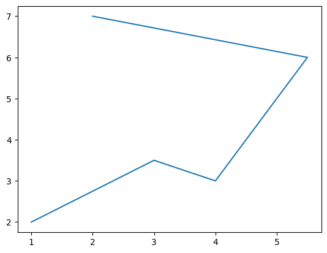

```python
plt.plot([1, 3, 4, 5.5, 2], [2, 3.5, 3, 6, 7]) # parametry: ciąg współrzędnych x, ciąg współrzędnych y
plt.show() # w notatniku można pominąć
```

```python
xs = [1, 3, 4, 5.5, 2]
ys = [2, 3.5, 3, 6, 7]
```

Bardzo dużo opcji rysowania (i upiększania):

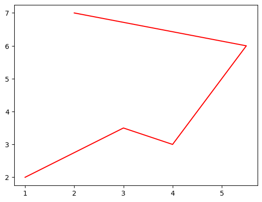

```python
plt.plot(xs, ys, color="red") # jeden ze sposobów przekazywania "nazwanych" parametrów funkcji
plt.show()
```

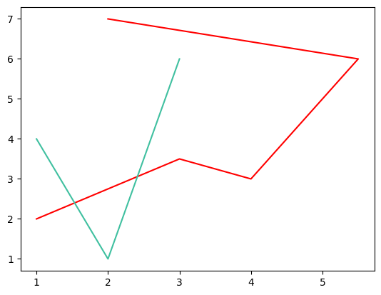

```python
plt.plot(xs, ys, color="red")
plt.plot([1, 2, 3], [4, 1, 6], color="#40C0A0") # kolor html
plt.show()
```

Dużo innych opcji:

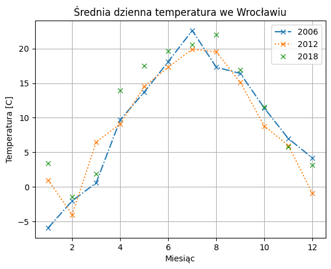

```python
from matplotlib.pyplot import plot, show, legend, xlabel, ylabel, title, grid

temp_2006 = [-5.9, -2.0, 0.6, 9.7, 13.7, 18.1, 22.6, 17.3, 16.4, 11.4, 7.0, 4.2]
temp_2012 = [1.0, -4.0, 6.5, 9.1, 14.5, 17.3, 19.9, 19.5, 15.1, 8.8, 6.0, -0.9]
temp_2018 = [3.4, -1.4, 1.9, 13.9, 17.5, 19.6, 20.6, 22.0, 16.9, 11.6, 5.8, 3.2]

months = range(1, 13)

plot(months, temp_2006, marker='x', linestyle='dashdot')
plot(months, temp_2012, marker='x', linestyle='dotted')
plot(months, temp_2018, marker='x', linestyle='None')

title("Średnia dzienna temperatura we Wrocławiu")
xlabel("Miesiąc")
ylabel("Temperatura [C]")
legend([2006, 2012, 2018])

grid()
show()
```

### Listy składane

```python
lst = [i ** 2 for i in range(10)]
print(lst)
```

```
[0, 1, 4, 9, 16, 25, 36, 49, 64, 81]
```

Ogólniej:  
`[expression for name in sequence]` gdzie `expression` to wyrażenie, w którym może pojawiać się nazwa `name`.

Przydatne w rysowaniu wykresów funkcji:

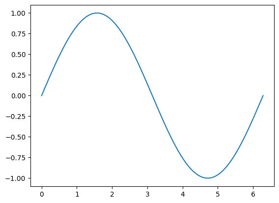

```python
xs = [2 * math.pi * i / 100 for i in range(101)]
ys = [math.sin(x) for x in xs]
plt.plot(xs, ys)
plt.show()
```

**Uwaga**. Na następnym wykładzie pojawi się jeszcze lepszy sposób reprezentacji ciągów liczb (z użyciem modułu `numpy`).